# DS 807 Assignment 4

Dagny Wilkins, Drew Rigney, Aleena Linson

Due: 4/25/2022 by 5:30 pm

## Group Assignment Guidelines

#### Purpose:

- Learning Outcomes measured in this assignment: LO1 to LO5
- Content knowledge you’ll gain from doing this assignment: principle components and supervised neural networks

#### Criteria:

- For this assignment, you can work in groups of up to 3 people.
- Submission: You have two options. Please choose as you wish.
  1. Upload the knitted document on Canvas.
  2. Publish your final output in RPubs. https://rpubs.com/about/getting-started

#### Tasks

1. Install the required libraries if you have not done so.
2. Add the libraries in the R chunk above.
3. For this assignment, we will be using heart data set. The entire data set is available here: https://www.kaggle.com/ronitf/heart-disease-uci

The following chunk reads the data:

```r
heart=read_csv("https://unh.box.com/shared/static/n55ois498oe9d7jau8dq81tozldlvjdo.csv")
head(heart)
```

```
## # A tibble: 6 x 14
##     age   sex    cp trestbps  chol   fbs restecg thalach exang oldpeak slope
##   <dbl> <dbl> <dbl>    <dbl> <dbl> <dbl>   <dbl>   <dbl> <dbl>   <dbl> <dbl>
## 1    63     1     3      145   233     1       0     150     0     2.3     0
## 2    37     1     2      130   250     0       1     187     0     3.5     0
## 3    41     0     1      130   204     0       0     172     0     1.4     2
## 4    56     1     1      120   236     0       1     178     0     0.8     2
## 5    57     0     0      120   354     0       1     163     1     0.6     2
## 6    57     1     0      140   192     0       1     148     0     0.4     1
## # ... with 3 more variables: ca <dbl>, thal <dbl>, target <dbl>
```

## PCA

4. (20 points) Perform a PCA analysis. While doing so:
   - Which function did you use?

   We decided to use the prcomp function.
   - Did you scale your data?

   Yes, we scaled the data. Scaling the data is very important when it comes to PCA and distance based algorithms (ie clustering).

It seems like five is the best number of components based on the cumulative proportion.

```r
heart.pca = prcomp(heart[,-c(2,3,6,7,9,11,13,14)], scale=TRUE, center=TRUE)

summary(heart.pca)
```

```
## Importance of components:
##                           PC1    PC2    PC3   PC4    PC5    PC6
## Standard deviation     1.4106 1.0418 0.9437 0.900 0.8710 0.6823
## Proportion of Variance 0.3316 0.1809 0.1484 0.135 0.1265 0.0776
## Cumulative Proportion  0.3316 0.5125 0.6609 0.796 0.9224 1.0000
```

```r
heart_cor=cor(heart[,-c(2,3,6,7,9,11,13,14)])
heart_cor
```

```
##                 age    trestbps         chol      thalach     oldpeak
## age       1.0000000  0.27935091  0.213677957 -0.398521938  0.21001257
## trestbps  0.2793509  1.00000000  0.123174207 -0.046697728  0.19321647
## chol      0.2136780  0.12317421  1.000000000 -0.009939839  0.05395192
## thalach  -0.3985219 -0.04669773 -0.009939839  1.000000000 -0.34418695
## oldpeak   0.2100126  0.19321647  0.053951920 -0.344186948  1.00000000
## ca        0.2763262  0.10138899  0.070510925 -0.213176928  0.22268232
##                   ca
## age       0.27632624
## trestbps  0.10138899
## chol      0.07051093
## thalach  -0.21317693
## oldpeak   0.22268232
## ca        1.00000000
```

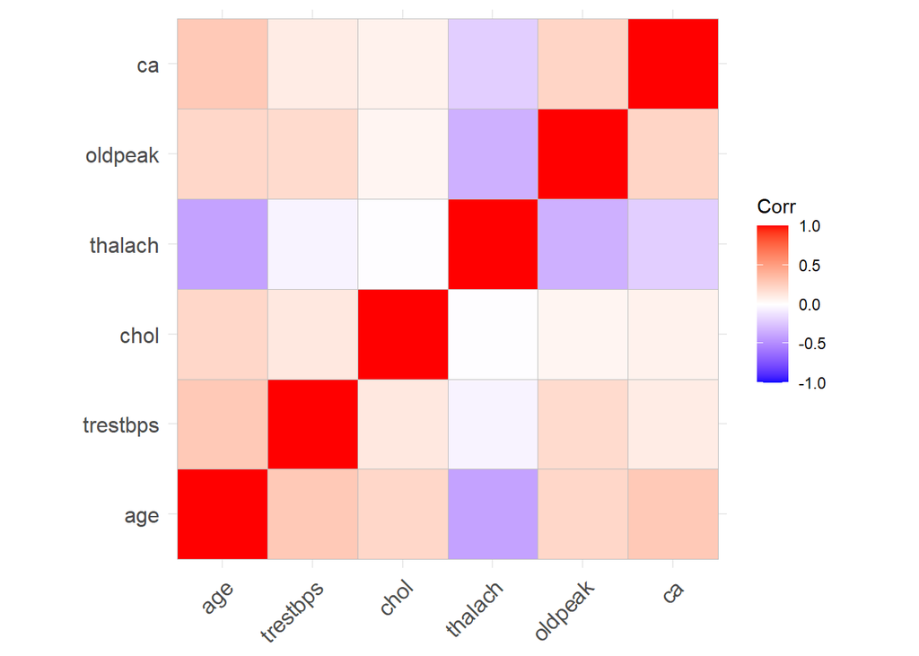

```r
ggcorrplot(heart_cor)
```

5. (20 points) Looking at biplot and scree plots, were you able to reduce the dimensionality of your data?

It seems like the elbow of the scree plot occurs at the second component. Dimensionality wasn’t a big concern for this data set because a lot of the variables needed to be removed due to their categorical nature (only 6 remained) and reducing the dimensionality through PCA only removed one component. It only reduced it by one since the first couple of components didn’t strongly explain the variances. It makes sense that to be able to explain the variability in the data we need to use at least 5 principle components. Overall, we were not able to reduce the dimensionality very much; however, this was expected since the data is not high dimensional.

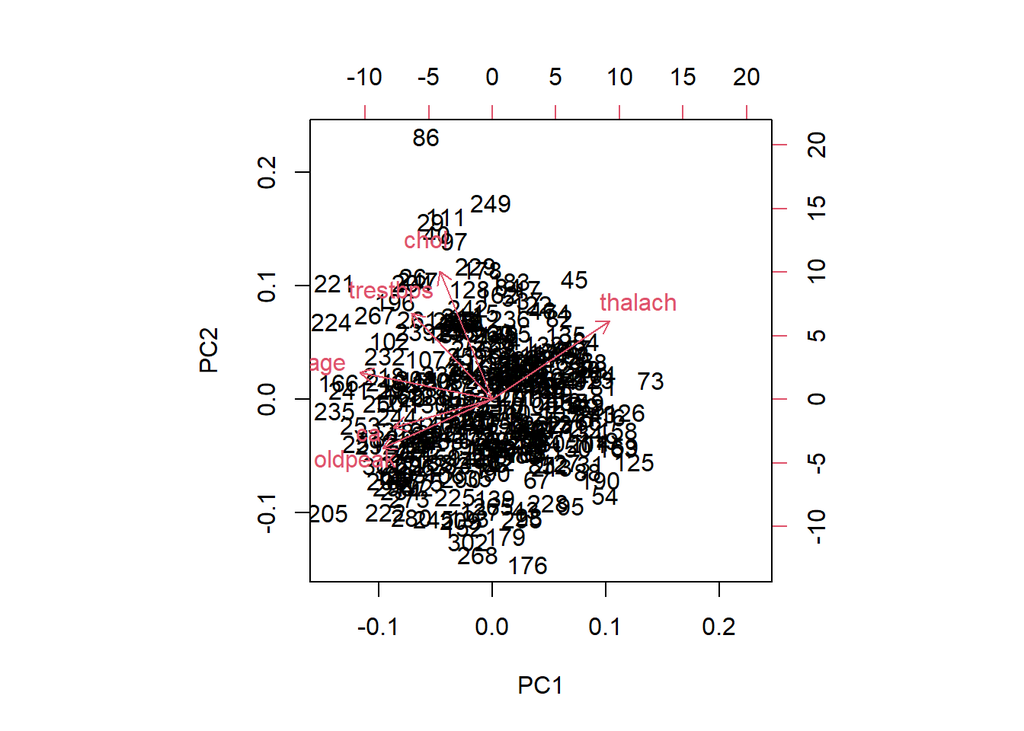

```r
biplot(heart.pca)
```

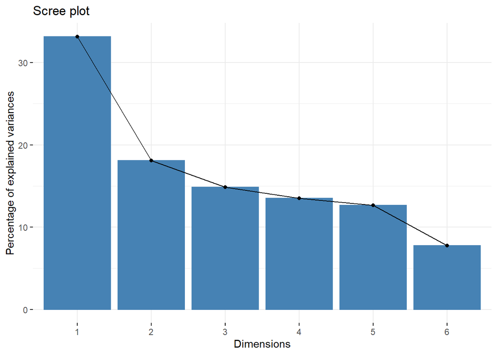

```r
fviz_eig(heart.pca)
```

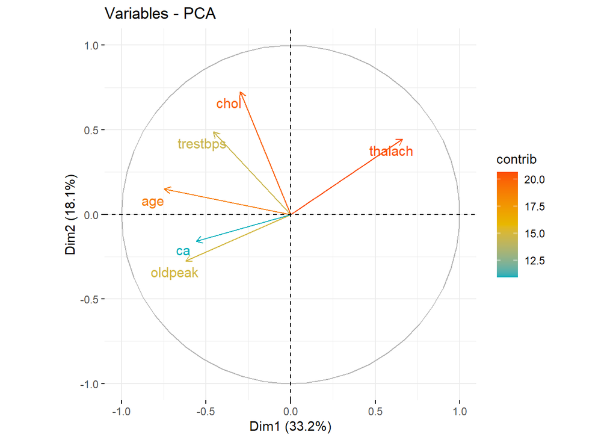

```r
fviz_pca_var(heart.pca,
             col.var = "contrib", # Color by contributions to the PC
             gradient.cols = c("#00AFBB", "#E7B800", "#FC4E07"),
             repel = TRUE     # Avoid text overlapping
             )
```

6. (15 points) What did you gain by doing a PCA?

In this case, performing principle component analysis allowed us to gain a better understanding of the structure of the data, and we were able to determine that we do not have a very high dimensional data set. It only removed one variable component from the model, slightly reducing the dimensionality of the data. We are also able to see that almost all the variables have a very large impact on explaining variability in the data as we can only drop one of the principle components and remain above 85% of the variance being explained. It also eliminated any multicollinearity concerns that was evident in the correlation plot above.

### Clustering

7. (25 points) Using principle components corresponding to at least 85% of the variation, perform a mixture model clustering algorithm. Which algorithm you chose and why? How did you determine the number of clusters?

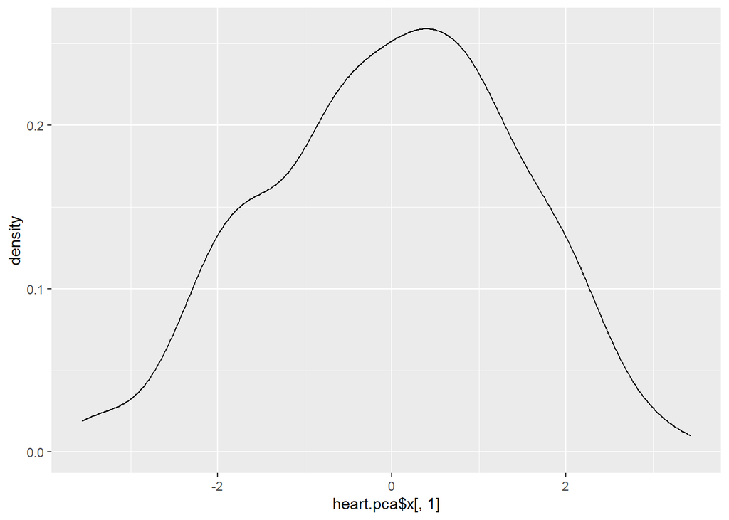

```r
cluster = data.frame(heart.pca$x[,1:5])

ggplot(cluster, aes(x = heart.pca$x[,1] )) +
  geom_density()
```

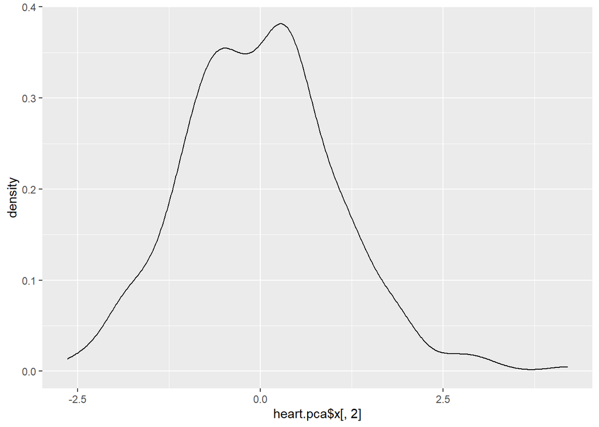

```r
ggplot(cluster, aes(x = heart.pca$x[,2] )) +
  geom_density()
```

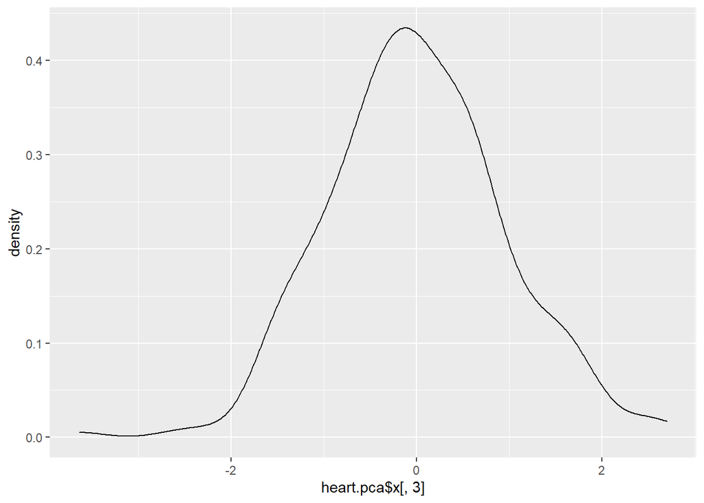

```r
ggplot(cluster, aes(x = heart.pca$x[,3] )) +
  geom_density()
```

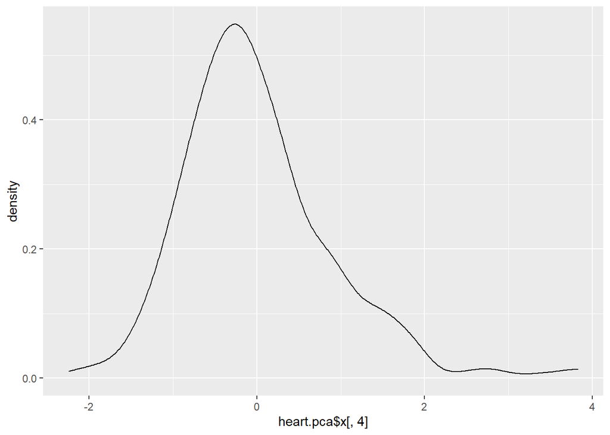

```r
ggplot(cluster, aes(x = heart.pca$x[,4] )) +
  geom_density()
```

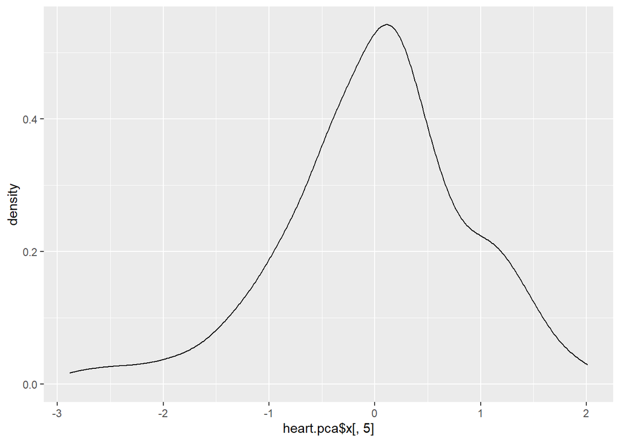

```r
ggplot(cluster, aes(x = heart.pca$x[,5] )) +
  geom_density()
```

```r
#2 cluster model
heartm1=Mclust(heart.pca$x[,1:5], 2)
summary(heartm1)
```

```
## ----------------------------------------------------
## Gaussian finite mixture model fitted by EM algorithm
## ----------------------------------------------------
##
## Mclust VVE (ellipsoidal, equal orientation) model with 2 components:
##
##  log-likelihood   n df       BIC       ICL
##       -1908.813 303 31 -3994.752 -4019.525
##
## Clustering table:
##   1   2
## 153 150
```

```r
#"optimal" # of clusters
heartm2=Mclust(heart.pca$x[,1:5])
summary(heartm2)
```

```
## ----------------------------------------------------
## Gaussian finite mixture model fitted by EM algorithm
## ----------------------------------------------------
##
## Mclust VVE (ellipsoidal, equal orientation) model with 5 components:
##
##  log-likelihood   n df       BIC       ICL
##       -1763.505 303 64 -3892.688 -3968.673
##
## Clustering table:
##   1   2   3   4   5
##  61  30 113  38  61
```

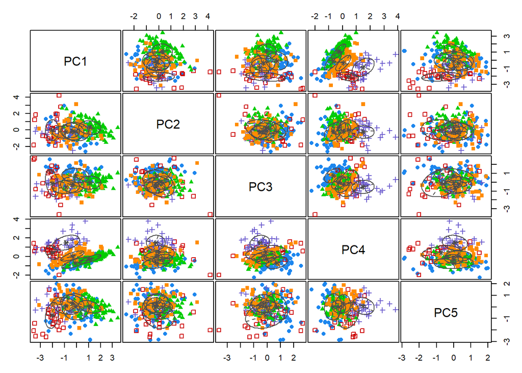

```r
plot(heartm2, what = "classification")
```

8. (20 points) What is/are your finding(s) based on your clustering algorithm? Explain your findings to a nontechnical audience, i.e., your parents or siblings.